# Campfire Response Times

## Comparing Response Times to the Camp Fire of the Public and Local Officials

### Olivia Plazanet, Madeline Hoshko and Taylor Hinchliff

## Introduction and Background

## Introduction

- For our topic, we chose to examine the Tweet response times of official accounts such as CalFire, the Butte County Sheriff, and others during the Camp Fire, the deadliest and most destructive wildfire in California history and the most expensive natural disaster in the world in 2018 in terms of insured losses (USA Today, 2019).
- Investigating these kinds of response times is important, because of the need of accurate, timely warnings and other information should a disaster, natural or otherwise, occur and threaten the lives and livelihoods of people.
- In the case of previous popular means of communication and warning such as radio, local television, and even direct phone calls, we can no longer rely on these methods reaching every citizen in order to warn them about an impending disaster. Instead, other methods are needed that are more widely used.
- But unfortunately, a tool is only as useful as the person who uses it. If used incorrectly or inappropriately, it could lead to further danger by misleading or misinforming the public. That is why quick, accurate, and widespread posts with pertinent information can be useful in times of emergency.
- Algorithms, or set instructions used to perform a simple task in programming, can be used in Twitter to see “trending” or popular terms and hashtags, which can be incredibly useful in times of a crisis if they are used to identify where and what is happening.
- That is why it is also very important to examine the times it takes for officials to issue official information and warnings to the public, such as evacuation notices. And for that reason we have chosen to study the response times of official accounts during the Camp Fire on Twitter, one of the most popular social media platforms in the United States.

## Why Use Twitter?

- Social network Twitter is particularly popular in the United States, where as of April 2020, the microblogging service had audience reach of 64.2 million users.
- In the Nielsen ratings for 2018-19, the broadcast networks averaged 28.5 million viewers in primetime, a decline of 7.3 million viewers (20 percent) since 2014-15, so television is becoming less helpful in distributing timely information.
- Radio is also a poor choice for the distribution of time-sensitive announcements, The Infinite Dial research for the past 12 years shows how the radio has been declining in the home. “In 2008 only 4% of Americans reported having no radio in their home, as compared to 32% today (Radio Ink, 2020).
- Not only is social media used by a wide variety of demographics, but it is also used for a significant portion of those citizens’ days and is starting to replace time spent with traditional media. For local governments that have primarily focused their citizen communication strategies around news distribution through traditional media outlets, we now know that social media serves as a more direct and more impactful way to communicate with citizens (EfficientGov, 2018). News now usually appears on social media first.
  - Social media crosses geographic boundaries more quickly.
  - Social channels are informed by multiple individuals firsthand, often through unofficial sources, but sometimes those who are direct witnesses to events.
  - Social media is commented upon by active social media users who further share and distribute content.
- Journalists watch social media to identify and report breaking news stories. According to Insignia, 77 percent of journalists say social media is important to them for learning about potential stories more quickly, and the same percentage say social media is important in reporting stories more quickly (Elliott 2018).

## Background and Lit Review

- Disaster Response and Twitter
  - Why is Twitter data important during disasters?
    - Twitter gives everyone a “real-time view” of disasters, allowing them to get information quickly from official sources regarding their safety (Ford, 2018).
  - “Given the volume of data produced, manually managing this process in the immediate aftermath of a crisis is not always practical. There is also often a need for unique updates related to particular topics within and across organizations” (Ford, 2018).
  - Some groups are coming up with programs specifically tailored towards combing Twitter during disasters for noun-verb pairs that might come up during disasters like “bridge collapsed” and “person trapped”. This could help official response times in future disasters (Ford, 2018).

## Background and Lit Review

- Potential Flaws in Phone-Based Warning Systems
  - “Call failure reports released by the Butte County Sheriff’s Office at the request of The Times show that the first evacuation orders requested by firefighters at the scene of the massive blaze frequently failed to connect. About as many calls went to voicemail as were answered by a live person (St. John and Serna, 2018).”
  - If officials are not able to make timely announcements and easily warn the public of a looming disaster, this presents a real problem within our system.
  - In the case of the Camp Fire, the police chief of Paradise said “there was no time for a citywide evacuation order — the city’s own system went down in the midst of a partial order” (St. John and Serna, 2018). This shows a need for a wide array of emergency notification methods, and with California being the state with the largest amount of Twitter users, the platform seems perfect to fit the role of one of these notification methods (Stirtz, 2020).

## Background and Lit Review

- Refiguration of disaster social relations
  - The proliferation of new communication technologies is replacing traditional media when it comes to the flow of information, there is a transformation in the visibility of disasters (Cottle 2014).
  - Plays a more progressive part in disasters: connected individuals are becoming more central in emergency responses in humanitarian crisis situations (Cottle 2014).
  - “Challenging the top-down, elite dominated communications” (Cottle 2014) There is a civilian surge of information as well as worldwide engagement because of fast-flowing information, collaboration between citizens, disaster relief agencies, volunteers, and public figures (Cottle 2014).

## Background and Lit Review

- Limits to crisis data
  - Once a disaster occurs, data collection starts. However, using social media platforms such as Twitter can create analytical and ethical oversights. Not everybody has access to the internet, where the disaster occurred there can be power outages, etc (Crawford and Finn 2015).
  - Before social media, traditional media was state-controlled, and governments were used to it, but that changed in more recent years (Crawford and Finn 2015).
  - The Twitter algorithm can influence the way tweets are created or how they are retweeted; “bots” can also impede data-collection (Crawford and Finn 2015).
  - People cannot control how their data is used, which can pose a privacy issue. It is important to examine underlying assumptions when using social or mobile data (Crawford and Finn 2015).

## Research Problem and Topic Area

- How timely were the twitter accounts run by public officials and emergency services when it came to disseminating important and crucial information to the public during the Camp Fire? We will create a timeline of events to illustrate this problem.
- While there is a large amount of research that has been done regarding the usefulness of social media and its innovative uses in emergency management, the majority of the case studies have revolved around incidents such as earthquakes. In a study conducted by the US Department of Homeland Security in 2013, out of the six cases that were examined only one of them pertained to wildfires. One of the goals of our research is to examine the effectiveness of social media in the role of emergency management and expand upon its usefulness in cases of emergencies, in this case specifically the Camp Fire.

## Data Introduction

- 74,099 tweets were collected by the Spring 2020 Advanced Data Science class at CSU, Chico. Tweets were collected using the rtweet (Kearney MW 2019) package using R 3.6.2 (R Core Team) beginning the morning of November 11, 2018.
- A timeline of events from the morning of November 8, 2018 was derived from the Chico Enterprise-Record. (Epley)
- Each record in the data represents an individual tweet and contains all the information regarding the tweet in terms of who posted it, the times its been retweeted, and more. We are looking specifically into the time of day each tweet was posted to look into the response times of organizations in charge of monitoring the situation.
- During the data collection the only data that needed to be discarded were results that turned up not belonging to our query as they were not in English. Otherwise, our query that filtered tweets to include one or more of the following: #CampFire, #campfire, #paradise, #Paradise or @CALFIRE_ButteCo" during the correct time frame.
- The reliability of data collection is important to our research question as we are interested in few accounts and want to ensure we have the most information as possible and that it is accurate since we are concerned with such a small amount of data compared to the entirety of the dataset.
- We are observing tweets regarding seven public figures’ and organizations’ twitter accounts that were instrumental in dispersing information regarding the Camp Fire, specifically: @Cal_Fire, @CalFire_ButteCo, @ButteSherriff, @ChicoFD, @CountyOfButte, @Paradise_CA, and @ChicoPolice.
- The data is defined to be a media source when it belongs to one of the previous accounts, while all others are classified as public.

## Methods

- Variable Creation: To successfully compare the response time of the following accounts: @Cal_Fire, @CalFire_ButteCo, @ButteSherriff, @ChicoFD, @CountyOfButte, @Paradise_CA, and @ChicoPolice to the real life timing of events we referenced Chico Enterprise-Record’s timeline of the fire. (Epley) We populated a data frame with each event and time as specified by Chico Enterprise-Record.
- Data Analysis: We analyzed the specific timing of emergency services and government entities’ tweets regarding pertinent information in relationship to the real life events through a timeline that incorporates both the twitter data and the derived timeline data in one merged timeline plot. We additionally created a timeline documenting the comparison between times of general public tweets and tweets that came from our selected local media sources stated above. Both timelines show the event description or tweet content along with the time the event or tweet occured.

## Description of variables being used

- The data for the Camp Fire that we were most interested in involved initial response times, so we filtered down the dataset to only include tweets that occurred during the first six hours from the fire starting.
- The variables used throughout include:
  - Tweet content (text)
  - User’s Twitter Handle (screen_name)
  - Whether the tweet was a retweet (is_retweet)
  - Time the tweet was created (created_at_pst)
  - The events derived from Chico Enterprise-Record’s timeline (Epley)

## Results

## Univariate Description of Explanatory Measure

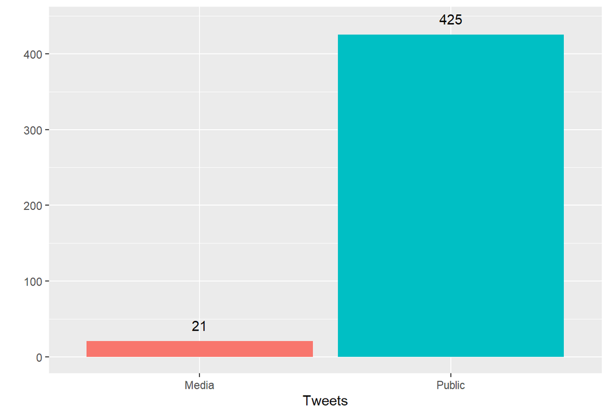

## Univariate Description of Response Measure

Our response measure is the time of the tweets as we are interested in the difference in time between real life events and tweets. Here we show the overall timeline of the first six hours of tweets that we will be referencing throughout.

- | Time of First Tweet |
  | --- |
  | 2018-11-08 06:51:47 |

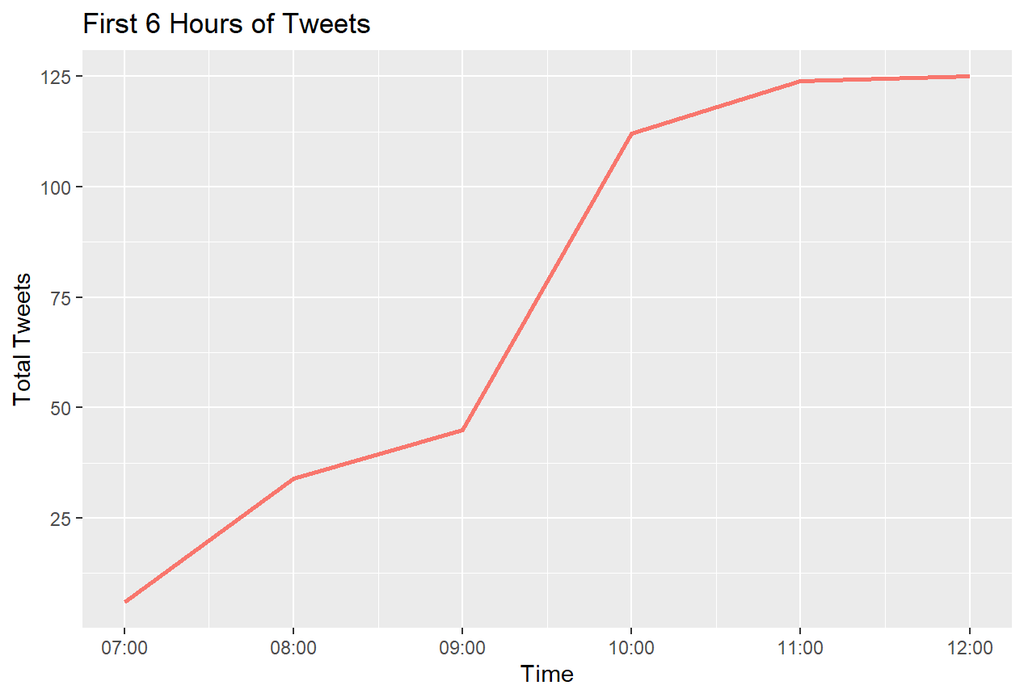

## Bivariate Description of Response

The response times and amount of responses for each account can be shown here to display the accounts that were most involved within the first hours of the fire. The media’s first response to the fire on Twitter appears at 06:51:47 by CAL FIRE Butte County

| User | Time of First Tweet |
| --- | --- |
| ButteSheriff | 2018-11-08 07:23:02 |
| CALFIRE_ButteCo | 2018-11-08 06:51:47 |
| ChicoFD | 2018-11-08 10:46:27 |

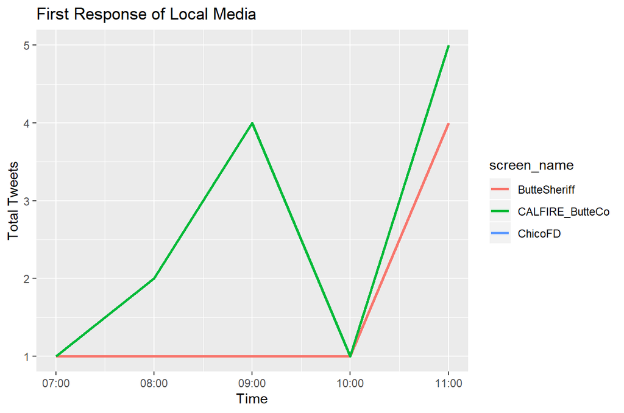

## Public Tweets

Here we can see the activity of public accounts to see the frequency of tweets. What’s important to note is the vast number of retweets, showing the number of tweets that are typically dispersing the media’s tweets to reach a wider audience.

The first tweet by a public user closely followed CAL FIRE Butte County’s at 06:54:55

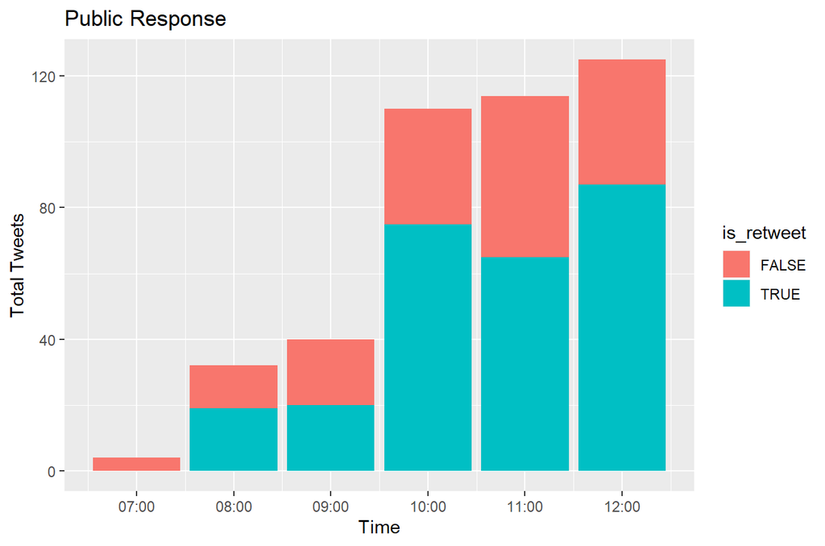

## The Media Response vs Real-Time Events

In the following timeline each dot signifies a tweet or event to show tweet times in comparison to the real event times. The majority of the tweets shown are evacuation warnings and orders.

[interactive chart not shown]

## The Media Response vs Public Response

After eliminating retweets the following timeline compares the tweet frequency of the public vs the media for the morning up until 10:00 AM.

[interactive chart not shown]

## References

Cottle, Simon. (2014). Rethinking Media and Disasters in a Global Age: What’s Changed and Why It Matters. Media, War & Conflict. 7. 3-22.10.1177/1750635213513229. https://www.researchgate.net/publication/270633894_Rethinking_Media_and_Disasters_in_a_Global_Age_What's_Changed_and_Why_It_Matters

Elliott, Jennifer. “8 Best Practices for Emergency Communications on Social Media.” EfficientGov, 19 July 2018, https://www.efficientgov.com/community-engagement/articles/8-best-practices-for-emergency-communications-on-social-media-vwZS7OO5eoblrs3G/.

Epley, Robin (November 8, 2019). “Timeline: Breaking down Nov. 8 - the Day the Camp Fire Sparked.” Chico Enterprise-Record, Chico Enterprise-Record https://www.chicoer.com/2019/11/07/timeline-breaking-down-nov-8-the-day-the-camp-fire-sparked/.

Ford, Jordan. “Improving Disaster Response through Twitter Data.” Penn State University, 2018, https://news.psu.edu/story/527730/2018/07/10/research/improving-disaster-response-through-twitter-data.

Kearney MW (2019). “rtweet: Collecting and analyzing Twitter data.” Journal of Open Source Software, 4(42), 1829. Doi: 10.21105/joss.01829, R package version 0.7.0, https://joss.theoj.org/papers/10.21105/joss.01829.

## References cont.

R Core Team (2019). R: A Language and Environment for Statistical Computing. R Foundation for Statistical Computing, Vienna, Austria. URL https://www.R-project.org.

Radio Ink (March 3, 2020). “The Decline of the Home Radio”. https://radioink.com/2020/03/03/the-decline-of-the-home-radio/

Rice, Doyle (January 8, 2019). “USA had world’s 3 costliest natural disasters in 2018, and Camp Fire was the worst”. USA Today.

St. John, Paige, and Joseph Serna. “Camp Fire Evacuation Warnings Failed to Reach More than a Third of Residents Meant to Receive Calls.” Los Angeles Times, 1 Dec. 2018, https://www.latimes.com/local/california/la-me-ln-paradise-evacuation-warnings-20181130-story.html.

Stirtz, Kevin. “Twitter Ranking: Which States Twitter the Most?” All Business, Dun & Bradstreet, 14 May 2009, https://www.allbusiness.com/twitter-ranking-which-states-twitter-the-most-12329567-1.html.